# Resistenza termica

Nel caso il sistema in esame sia monodimensionale e allo stato stazionario, è possibile modellare il trasporto di energia introducendo il concetto di resistenza al pari di quello definito nel caso di sistemi elettrici.
La forza motrice che muove il sistema è il gradiente di temperatura al pari di quella differenza di potenziale elettrico, mentre il flusso di calore è da considerare al pari del flusso di corrente elettrica I.
$$R_E = \frac{V}{I} \hspace{1cm} R_T = \frac{\Delta T}{Q}=\frac{L}{kA}$$ Il pedice T verrà omesso da qui in seguito.

## Conduzione

La portata di calore per conduzione viene definita come: $$R_T = \frac{L}{kA}$$

## Convezione

La portata di calore per la convezione, vale: $$Q=h A (T_s-T_{\inf})$$ Il valore di h può essere definito per il sistema a seconda delle condizioni di convezione naturale o forzata, mentre la temperatura $T_s$ è la temperatura alla parete, mentre $T_{\infty}$ è la temperatura lontano dalla parete. Posso definire la relazione che lega la convezione con la definizione della resistenza come: $$R = \frac{\Delta T}{Q} = \frac{1}{hA} $$

# Pannello composito a sandwich

## Pannello multistrato composto di 2 diversi materiali

Nell'esempio in esame si vogliono valutare l'influenza in un pannello sandwich dello spessore delle sezioni o della tipologia di materiale, in condizioni stazionarie.
La resistenza del sistema per come definito può essere descritta come 4 resistenze in serie. $$R_{TOT}=R_{conv,E}+R_1+R_2+R_{conv,I}$$ Il sistema risulta composto in definitiva da 4 resistenze che sono definite partendo da uno dei due lati definito come (1), la convezione esterna lato 1, la conduzione lato 1, la conduzinoe lato 2, e la convezione esterna lato 2.
Le condizioni di convezione lato 1 e 2 possono essere inserite modificando i valori di h1 o h2 all'interno dei range riportati tra i parametri.

### Costanti

```matlab
%Dimensioni della parete
W = 1;                     %Larghezza [m]
H = 2;                     %Altezza [m]
%Area
A = W*H;                     %Area perpendicolare

%Conduzione
%Spessore dei pannelli
L1 = 0.01;                 %Primo pannello [m]
L2 = 0.02;                 %Secondo pannello [m]

%Conducibilità termica
k1 = 0.5;                  %Conduttore [W/(m*K)];
k2 = 5;                    %Isolante [W/(m*K)];

%Convezione
h1 = 100;                  %Convezione naturale lato esterno (Per liquidi 50-1000 per gas 2-25) [W/(K*m^2)]
h2 = 10000;                %Convezione forzata lato interno (Per liquidi 100-20000 per gas 25-250) [W/(K*m^2)]

%Calcolo delle resistenze
%Convezione
RconvE = 1/(h1*A);         %[K/W]
RconvI = 1/(h2*A);         %[K/W]
%Conduzione
R1 = L1/(k1*A);            %[K/W]
R2 = L1/(k1*A);            %[K/W]

%Resistenza Totale
Rtot = RconvE + R1 + R1 + RconvI;       %[K/W]

%Stampa valori
fprintf('Resistenza lato interno per convezione:%3.5f [K/W] \nResistenza lato 1 per conduzione:%3.5f  [K/W] \nResistenza lato 2 per conduzione:%3.5f  [K/W] \nResistenza lato esterno per convezione:%3.5f [K/W]\nResistenza Totale:%3.5f [K/W]',RconvE,R1,R2,RconvI,Rtot)
```

```
Resistenza lato interno per convezione:0.00500 [K/W]
Resistenza lato 1 per conduzione:0.01000  [K/W]
Resistenza lato 2 per conduzione:0.01000  [K/W]
Resistenza lato esterno per convezione:0.00005 [K/W]
Resistenza Totale:0.02505 [K/W]
```

A seconda dei dati inseriti possiamo notare quali siano le resistenze più impattanti del sistema.  
Conoscendo il valore della resistenza totale del sistema è possibile andare a valutare diversi parametri, ad esempio vincolando le temperature nel bulk nelle conduzioni a seconda delle specifiche è possible valutare quale dovrà essere la portata termica da utilizzare per mantenere il sistema in condizioni stazionarie, al contrario imponendo il valore di un flusso costante tra gli strati della parete è possibile valutare la temperatura nel lato rimanente introducendo quella iniziale.

## Valutazione temperatura lato opposto della parete

```matlab
Q = 1000;            %Portata termica(Negativa perchè va nel verso opposto della direzione x)[J/s]
Tint = 200;          %Temperatura lato interno
T = Tint - Q*Rtot;   %Temperature finale
fprintf('La temperatura finale vale: %3.4f[K]',T)
```

```
La temperatura finale vale: 174.9500[K]
```

## Calcolo strato per strato

```matlab
%Convezione lato interno
Tint1 = Tint - Q*RconvE;
%Conduzione lato 1
x1=linspace(0,L1,100);
q=Q/A;
options = odeset('RelTol',1e-6);
[xsol1,Tsol1] = ode15s(@TBs,x1,Tint1,options,k1,q);
%Conduzione lato 2
fin = L2+L1;
x2=linspace(L1,fin,100);
Tin2 = Tsol1(length(Tsol1));
[xsol2,Tsol2] = ode15s(@TBs,x1,Tin2,options,k2,q);
%Convezione lato esterno
Tinest =Tsol2(length(Tsol2));
Test2 = Tinest - Q*RconvI;
fprintf('La temperatura finale vale: %3.4f[K]',Test2)
```

```
La temperatura finale vale: 167.4500[K]
```

## Grafici

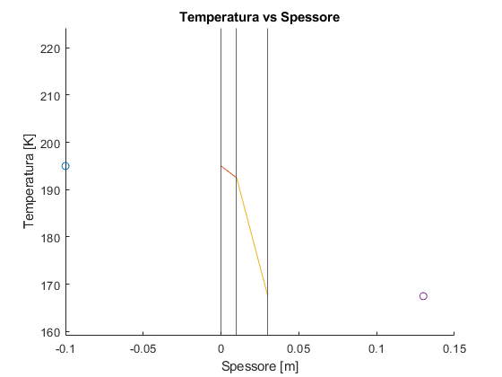

```matlab
scatter(-0.1,Tint1), hold on
plot(x1,Tsol1)
plot(x2,Tsol2)
scatter(0.13,Test2)
xlabel('Spessore [m]')
ylabel('Temperatura [K]')
title('Temperatura vs Spessore')
xline(0,'-')
xline(L1,'-')
xline(fin,'-')
Minx = -0.1;
Maxx = 0.15;
MinT = Test2*0.95;
MaxT = Tint1*1.15;
axis([Minx Maxx MinT MaxT])
```